# 梯度下降法优化权重

### 1. “学习”的本质是什么？

在进行下面的工作之前，我们需要回顾一下“学习行为”的本质。

你的大脑由1000亿个神经元组成。

神经元会长出很多“小手”和别的神经元连接在一起，这些小手叫做“神经突触”。

也就是说，神经元与神经元之间可以以不同的方式、不同的强度相互连接。

一个神经元如果想起作用，它一定要和其他的神经元相互连接，构成网络。未能和其他神经元连接的那些神经元只能“郁郁而终”——事实上，大约有一半的胚胎神经元最终将因为没有能够和其他的神经元建立有效连接而最终凋亡。

你在出生时就拥有了你一生中能拥有的几乎所有神经元。在你生命的头15个月左右，大脑神经元之间的神经突触连接数量就已经达到最大了。因此，你的一生中，神经元的数目不会显著增多，但会缓慢变少。

接下来，你学会了跑、跳、认识数字、背诵课文——这些“学习过程”无不是通过对神经元之间连接强度的“优化”而完成的。这在生物上叫做“突触的可塑性”。

在我们的一生中，大脑神经元的可塑性始终存在，神经元会一直生长变化，也说明我们具备“活到老，学到老”的潜力，我们的人生有无限的可能性。

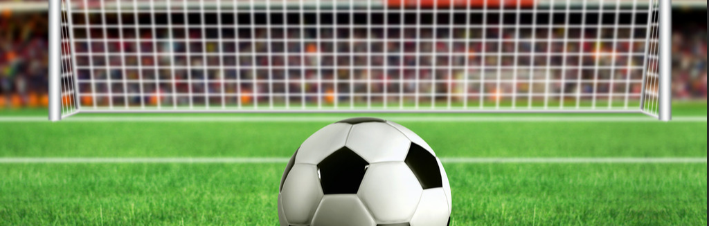

那么我们将以什么为依据进行学习过程，也就是将神经元之间的链接强度“修剪”成型的呢？

以你第一次学习踢足球为例。你站在点球点射门，足球偏离了左门柱1.5米。

足球偏离左门柱1.5米，是你“踢球”这个动作的结果。

你所完成的“踢球”这个动作，实际上是大脑中一系列神经元相互作用的结果。

也就是说，可以把足球偏离目标1.5米的误差，看做你的神经网络的作用结果。

如果我们想缩小误差的程度，就需要调整这个神经网络，也就是调整其间神经元的连接强度。

你可以想象，每一组连接强度的数值，都对应着一个偏差的数值。

这像极了函数$y = f(x)$中自变量x和因变量y的关系。

一言以蔽之

**一个神经网络的的输出与目标之间的误差E（因变量）是这个神经网络的链接权重矩阵$w_{i,j}$（自变量）的函数。**

$$E = f (w_{i,j})$$

**而学习行为，就是努力调整权重（自变量），使得误差（因变量）尽可能小的优化过程。**

总结一下，学习过程可以简化为2步：

**1.计算误差**

**2.利用误差来优化权重**

上节课，我们完成了第1步：**计算误差——误差的反向传播**

这节课，我们来学习第2步：**利用误差来更新参数——梯度下降法**

### 2. 找不到解析解怎么办？

上文书说道，神经网络的误差可以看做链接权重的函数。

到目前为止，我们已经理解了让误差反向传播到网络的每一层。为什么这样做呢？原因就是，我们使用误差来指导如何调整链接权重，从而改进神经网络输出的总体答案。

也就是说，我们现在知道这个函数的因变量Y，想求这个函数的自变量X。

对于一个简单的函数来说，这当然是很容易的。

比如，当你看到一个函数

$$y = (x + 1)^2 $$

想求得当 y = 4 时的 x 值。

你可以采用的办法是，解出

$$ x = \sqrt{y}-1 或 x = -\sqrt{y}-1 $$

将 y = 4 代入上式子，求得 x = 1 或 x = -3

我们把这种求得方程的解的方法称之为**解析法**(analytictechniques、analytic methods)。解析法求得的解称之为解析解（如$ x = \sqrt{y}-1 $）。解析解为一封闭形式(closed-form)的函数，我们可以把不同的 y 值代入进去，求得相应的 x 。

但是呢，并不是每个方程都有解析解,哪怕它看上去很简单，很像有解析解的样子：

$$y = x**5 - x + 1$$

当 y = 0 时求解 x = ？

看着很简单吧很像有解析解吧

哈哈哈哈

可是它没有。

但这并不代表我们就算不出来一个近似的 x 了。

我们观察它的图像：

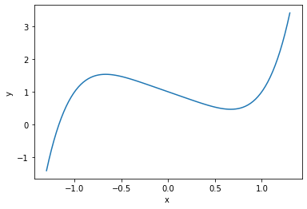

```python
import matplotlib.pyplot as plt
import numpy as np

#x的定义域
x = np.linspace(-1.3,1.3,100)

y = x**5 - x + 1

#告诉Jupiter notebook及时把图像显示出来
%matplotlib inline

#画图
plt.plot(x ,y)

#标注
plt.xlabel('x ')
plt.ylabel('y ')
```

x 取什么值的时候 y 看上去等于0呢？

我觉得就在 -1 到 -2之间吧...

算一算可知 x = -1 时 y = 1, x = -2 时 y = -29, 果然是一个小于0一个大于0呢...

```
    还能不能进一步逼近呢？

    我觉得就在x = - 1.1 到 -1.2之间吧...

    算一算可知 x = -1.1 时 y = 0.489, x = - 1.2 时 y = -0.288, 果然是一个小于0一个大于0呢...

            还能不能进一步逼近呢？

            我觉得就在x = - 1.16 到 -1.17之间吧...

            算一算可知 x = -1.16 时 y = 0.0597, x = -1.17 时 y = -0.0224, 果然是一个小于0一个大于0呢...
```

总之就这样一步一步地逼近（套娃）下去，我们可以得到一个近似解：

x = -1.167303978...

这种在不知道解析解的情况下采用某种计算方法，如数值逼近，插值的方法, 得到的解，就叫做**数值解**(numerical solution)。别人只能利用数值计算的结果, 而不能随意给出自变量并求出计算值。

接下来，我们就要求出我们所关心的函数

$$E = f (w_{i,j})$$

在E为最小值时

$w_{i,j}$的数值解。

那么有的同学要问了，我们为什么不适用一些微妙的代数方法直接计算出权重的解析解呢？

[figure not shown]

如果你真的很想求这个式子的解析解，就当我什么都没说...

### 3. 下山之路

好了，现在我们打定主意要求$$E = f (w_{i,j})$$

在E为最小值时

$w_{i,j}$的数值解了。

首先，我们来想象一下这个函数长成什么样子。

在这个式子中，误差 E 是很多权重矩阵$w_{i,j}$的函数。注意，这个$w_{i,j}$可不是一个权重，而是一堆权重$w_{1,1}$，$w_{1,2}$，$w_{1,3}$，$w_{2,1}$...也就是说这其实是个多元的方程,类似$Y = f (X_{1},X_{2},X_{3})$这样。

如果把一个因变量是一个维度，一个自变量当一个维度，那么很多个自变量就有很多个维度。

二维（一个因变量一个自变量），大概长这样：

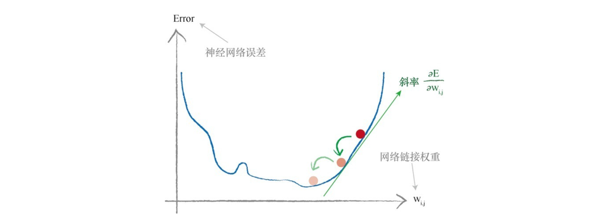

三维（一个因变量两个自变量），大概长这样：

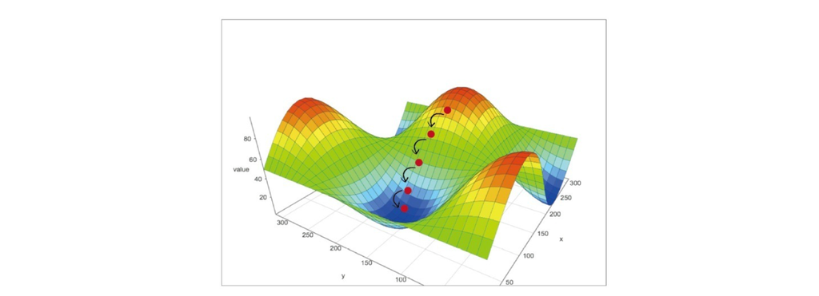

高维...我就想象不出来了，就只能和二维和三维类比来看。

我们干脆就先用二维的情况来类比吧。

在二维上，我们看到的很可能是一条随机曲线。没有确定的方程可以描述它。

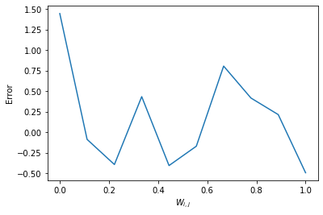

```python
#以下只是画个随机曲线

import matplotlib.pyplot as plt
import numpy as np

x = np.linspace(0,1,10)
y = np.random.randn(10,1)

%matplotlib inline

plt.plot(x ,y)

plt.xlabel('$W_{i,j}$')
plt.ylabel('Error')
```

我们要干的事情，是找出在在E为最小值时$w_{i,j}$的数值是多少，也就是说当链接强度是多少的时候整个系统的误差就最小了。

那么一般情况下我们如何找到一条曲线的最小值呢？

这就要应用到梯度下降的方法。

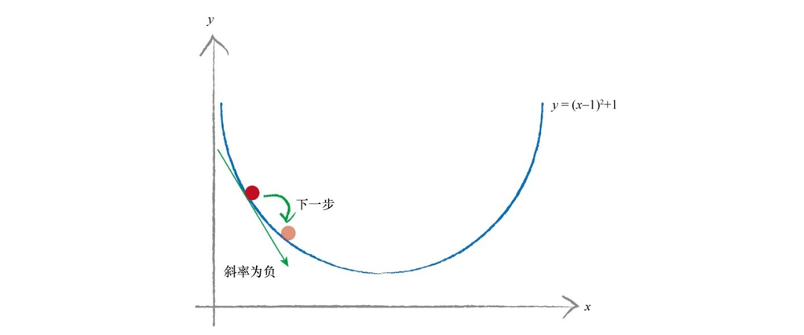

要应用梯度下降的方法，我们在曲线上随机选择一个起点。就像登山者，我们正站在这个地方，环顾四周，观察哪个方向是向下的。

在图上标记了当前情况下的斜率，其斜率为负。我们希望沿着向下的方向，因此我们沿着x 轴向右。也就是说，我们稍微地增加x 的值。这是登山者的第一步。你可以观察到，我们改进了我们的位置，向实际最小值靠近了一些。

我们假设在某个地方开始，如下图所示。

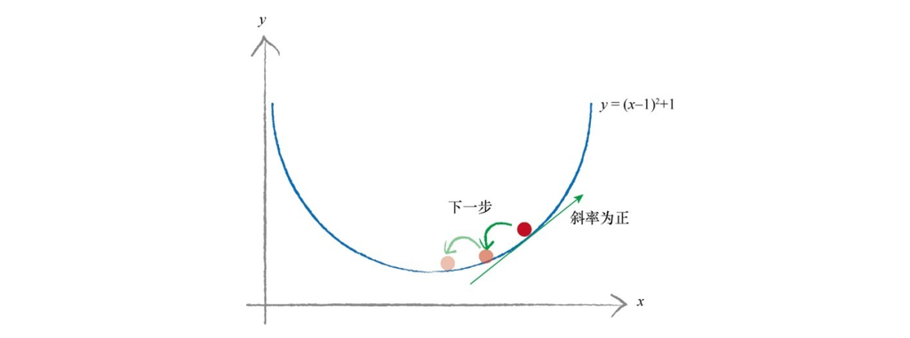

这一次，我们所在之处的斜率为正，因此我们向左移动。也就是说，我们稍微减小x 值。同样，你可以观察到我们已经改善了位置，向真实的最小值靠近了一些。我们可以继续这样操作，直到几乎不能改进为止，这样我们就确信已经到达了最小值。

我们就按照上面简单的规律（斜率的正负）来确定前进的方向。

下面还需要确定前进的步长。我们希望越接近最小值的时候，步长越短。（对于大多数光滑的连续函数，这个假设是合适的。）

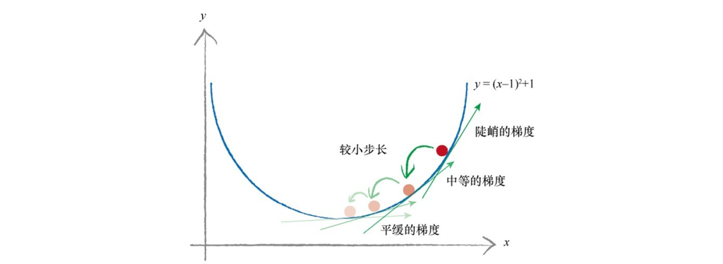

现在你已经理解了梯度下降法啦~

这种方法在处理二维的曲线时，并没有显得多么高效。然而当函数有很多自变量时，这种方法才真正地显现出它的亮点。y 也许不单单取决于x ，y 也可能取决于a、b、c、d、e和f。而神经网络的误差函数取决于许多的权重参数，这些参数通常有数百个呢！

### 4. 一通计算

现在我们已经了解了“斜率”在梯度下降法中的重要意义。

我们用这个式子来表示斜率：

$$ \dfrac {\partial E}{\partial w_{j,k}} $$

$$ \Delta w_{j,k} = new w_{j,k} - old w_{j,k} = - \alpha * \dfrac {\partial E}{\partial w_{j,k}} $$

正如我们先前所看到的，如果斜率为正，我们希望减小权重，如果斜率为负，我们希望增加权重，因此，我们要对斜率取反。符号α是一个因子，这个因子可以调节这些变化的强度，确保不会超调。我们通常称这个因子为学习率。

经过一系列计算，我们可以把$ \dfrac {\partial E}{\partial w_{j,k}} $表示为：

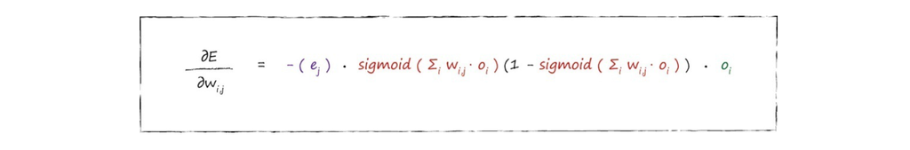

又经过一系列计算，我们可以把权重更新$ \Delta w_{j,k}$表示为计算机最喜欢的矩阵形式：

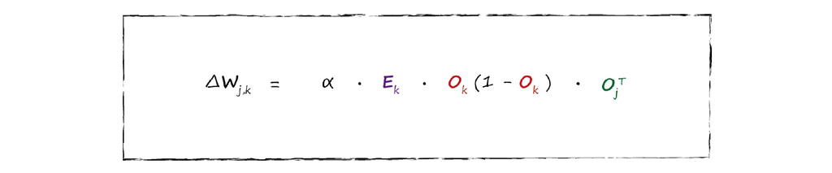

（如果对这一部分计算感兴趣请参阅《python神经网络编程》1.14）

于是今天的任务已经完成啦~

## 本讲要点

1.神经网络的误差是链接权重的函数。

2.学习过程的本质是：调整自变量——链接强度矩阵 $w_{ij}$ , 使得因变量——整个神经网络的输出与预期的误差值 达到最小。

3.如果函数有许多参数，难以得到解析解时，我们可以采用数值法逼近最优解。

4.梯度下降法是求解函数最小值的一种很好的数值法。

5.梯度下降法并不完美（不一定每一次都能得到最优解），所以不妨多试几次。